# Projekt zaliczeniowy

Dariusz Rozycki

2023-12-02

# Wprowadzenie

Zbiór danych zawiera informacje dotyczące zatrzymań drogowych dokonanych przez policję na przestrzeni kilku lat w rejonie San Francisco. Jeden wiersz to jedno zatrzymanie. Dane zostały pobrane ze strony: https://openpolicing.stanford.edu/data/

## Zmienne (już po modyfikacjach)

- **Data** (Date)
- **Szerokość geograficzna** (num)
- **Długość geograficzna** (num)
- **Wiek** (int)
- **Rasa** (Factor: white, asian/pacific islander, black, hispanic, other)
- **Płeć** (Factor: female, male)
- **Rezultat zatrzymania** (Factor: warning, citation, arrest)
- **Znaleziona kontrabanda** (Factor: no_search, FALSE, TRUE)
- **Kontrola osobista** (Factor: FALSE, TRUE)
- **Przeszukanie pojazdu** (Factor: FALSE, TRUE)
- **Pora dnia** (Factor: morning, afternoon, evening, night)

## Wykorzystywane pakiety

```r
library(tidyverse)
library(mice)
library(rmarkdown)
library(maps)
```

# Zapoznanie z danymi

## Wczytanie pliku

```r
data <- read.csv("ca_san_francisco_2020_04_01.csv", sep = ",")
```

## Sprawdzenie kilku pierwszych

```r
paged_table(head(data, 10))
```

|  | raw_row_number | date | time | location | lat | lng | district | subject_age | subject_race | subject_sex | type | arrest_made | citation_issued | warning_issued | outcome | contraband_found | search_conducted | search_vehicle | search_basis | reason_for_stop | raw_search_vehicle_description | raw_result_of_contact_description |
| --- | --- | --- | --- | --- | --- | --- | --- | --- | --- | --- | --- | --- | --- | --- | --- | --- | --- | --- | --- | --- | --- | --- |
| 1 | 869921 | 2014-08-01 | 00:01:00 | MASONIC AV & FELL ST | 37.77300 | -122.4459 | NA | NA | asian/pacific islander | female | vehicular | FALSE | FALSE | TRUE | warning | NA | FALSE | FALSE | NA | Mechanical or Non-Moving Violation (V.C.) | No Search | Warning |
| 2 | 869922 | 2014-08-01 | 00:01:00 | GEARY&10TH AV | 37.78090 | -122.4686 | NA | NA | black | male | vehicular | FALSE | TRUE | FALSE | citation | NA | FALSE | FALSE | NA | Mechanical or Non-Moving Violation (V.C.) | No Search | Citation |
| 3 | 869923 | 2014-08-01 | 00:15:00 | SUTTER N OCTAVIA ST | 37.78692 | -122.4267 | NA | NA | hispanic | male | vehicular | FALSE | TRUE | FALSE | citation | NA | FALSE | FALSE | NA | Mechanical or Non-Moving Violation (V.C.) | No Search | Citation |
| 4 | 869924 | 2014-08-01 | 00:18:00 | 3RD ST & DAVIDSON | 37.74638 | -122.3920 | NA | NA | hispanic | male | vehicular | FALSE | FALSE | TRUE | warning | NA | FALSE | FALSE | NA | Mechanical or Non-Moving Violation (V.C.) | No Search | Warning |
| 5 | 869925 | 2014-08-01 | 00:19:00 | DIVISADERO ST. & BUSH ST. | 37.78635 | -122.4400 | NA | NA | white | male | vehicular | FALSE | TRUE | FALSE | citation | NA | FALSE | FALSE | NA | Mechanical or Non-Moving Violation (V.C.) | No Search | Citation |
| 6 | 869926 | 2014-08-01 | 00:30:00 | 3RD ST AND GALVEZ AVE | 37.74108 | -122.3884 | NA | NA | black | male | vehicular | FALSE | TRUE | FALSE | citation | NA | FALSE | FALSE | NA | Mechanical or Non-Moving Violation (V.C.) | No Search | Citation |
| 7 | 869927 | 2014-08-01 | 00:30:00 | COLUMBUS AND BROADWAY | 37.79787 | -122.4067 | NA | NA | hispanic | male | vehicular | FALSE | TRUE | FALSE | citation | NA | FALSE | FALSE | NA | Moving Violation | No Search | Citation |
| 8 | 869928 | 2014-08-01 | 00:35:00 | INGALLS & QUESADA | 37.72912 | -122.3840 | NA | NA | black | female | vehicular | FALSE | TRUE | FALSE | citation | NA | FALSE | FALSE | NA | Mechanical or Non-Moving Violation (V.C.) | No Search | Citation |
| 9 | 869929 | 2014-08-01 | 01:00:00 | 17TH ST & BRYANT ST | 37.76432 | -122.4104 | NA | NA | black | male | vehicular | FALSE | TRUE | FALSE | citation | NA | FALSE | FALSE | NA | Mechanical or Non-Moving Violation (V.C.) | No Search | Citation |
| 10 | 869930 | 2014-08-01 | 01:00:00 | FULTON ST. & FUNSTON AV. | 37.77317 | -122.4713 | NA | NA | white | female | vehicular | FALSE | TRUE | FALSE | citation | NA | FALSE | FALSE | NA | Moving Violation | No Search | Citation |

## … i kilku ostatnich wartości

```r
paged_table(tail(data, 10))
```

|  | raw_row_number | date | time | location | lat | lng | district | subject_age | subject_race | subject_sex | type | arrest_made | citation_issued | warning_issued | outcome | contraband_found | search_conducted | search_vehicle | search_basis | reason_for_stop | raw_search_vehicle_description | raw_result_of_contact_description |
| --- | --- | --- | --- | --- | --- | --- | --- | --- | --- | --- | --- | --- | --- | --- | --- | --- | --- | --- | --- | --- | --- | --- |
| 905061 | 893000 | 2014-10-31 | 23:35:00 | POLK @ JACKSON | 37.79415 | -122.4214 | NA | NA | white | male | vehicular | FALSE | FALSE | TRUE | warning | NA | FALSE | FALSE | NA | Moving Violation | No Search | Warning |
| 905062 | 893001 | 2014-10-31 | 23:40:00 | DUBOCE/BELCHER | 37.76939 | -122.4303 | NA | NA | other | male | vehicular | FALSE | TRUE | FALSE | citation | NA | FALSE | FALSE | NA | Moving Violation | No Search | Citation |
| 905063 | 893002 | 2014-10-31 | 23:41:00 | OAK & PIERCE | 37.77356 | -122.4341 | NA | NA | other | male | vehicular | FALSE | TRUE | FALSE | citation | NA | FALSE | FALSE | NA | Moving Violation | No Search | Citation |
| 905064 | 893003 | 2014-10-31 | 23:45:00 | RHODE ISLAND & MARIPOSA | 37.76352 | -122.4025 | NA | NA | other | male | vehicular | FALSE | TRUE | FALSE | citation | NA | FALSE | FALSE | NA | Moving Violation | No Search | Citation |
| 905065 | 893004 | 2014-10-31 | 23:46:00 | 655 SUTTER STREET | 37.78876 | -122.4111 | NA | NA | white | female | vehicular | FALSE | FALSE | TRUE | warning | NA | FALSE | FALSE | NA | Moving Violation | No Search | Warning |
| 905066 | 893005 | 2014-10-31 | 23:47:00 | ORTEGA ST & 38TH AVE | 37.75148 | -122.4967 | NA | NA | white | male | vehicular | FALSE | FALSE | TRUE | warning | NA | FALSE | FALSE | NA | Moving Violation | No Search | Warning |
| 905067 | 893006 | 2014-10-31 | 23:48:00 | DUBOCE/BELCHER | 37.76939 | -122.4303 | NA | NA | asian/pacific islander | male | vehicular | FALSE | TRUE | FALSE | citation | NA | FALSE | FALSE | NA | Moving Violation | No Search | Citation |
| 905068 | 893007 | 2014-10-31 | 23:49:00 | NEW MONTGOMERY & STEVENSON | 37.78830 | -122.4015 | NA | NA | white | male | vehicular | FALSE | TRUE | FALSE | citation | NA | FALSE | FALSE | NA | Moving Violation | No Search | Citation |
| 905069 | 893008 | 2014-10-31 | 23:50:00 | BURKE & 3RD | 37.74501 | -122.3871 | NA | NA | black | male | vehicular | FALSE | FALSE | TRUE | warning | NA | FALSE | FALSE | NA | Mechanical or Non-Moving Violation (V.C.) | No Search | Warning |
| 905070 | 893009 | 2014-10-31 | 23:50:00 | FILLMORE/WALLER | 37.77132 | -122.4305 | NA | NA | white | male | vehicular | FALSE | TRUE | FALSE | citation | NA | FALSE | FALSE | NA | Moving Violation | No Search | Citation |

## Poznanie struktury danych

```r
str(data)
```

```
## 'data.frame':    905070 obs. of  22 variables:
##  $ raw_row_number                   : chr  "869921" "869922" "869923" "869924" ...
##  $ date                             : chr  "2014-08-01" "2014-08-01" "2014-08-01" "2014-08-01" ...
##  $ time                             : chr  "00:01:00" "00:01:00" "00:15:00" "00:18:00" ...
##  $ location                         : chr  "MASONIC AV & FELL ST" "GEARY&10TH AV" "SUTTER N OCTAVIA ST" "3RD ST & DAVIDSON" ...
##  $ lat                              : num  37.8 37.8 37.8 37.7 37.8 ...
##  $ lng                              : num  -122 -122 -122 -122 -122 ...
##  $ district                         : chr  NA NA NA NA ...
##  $ subject_age                      : int  NA NA NA NA NA NA NA NA NA NA ...
##  $ subject_race                     : chr  "asian/pacific islander" "black" "hispanic" "hispanic" ...
##  $ subject_sex                      : chr  "female" "male" "male" "male" ...
##  $ type                             : chr  "vehicular" "vehicular" "vehicular" "vehicular" ...
##  $ arrest_made                      : logi  FALSE FALSE FALSE FALSE FALSE FALSE ...
##  $ citation_issued                  : logi  FALSE TRUE TRUE FALSE TRUE TRUE ...
##  $ warning_issued                   : logi  TRUE FALSE FALSE TRUE FALSE FALSE ...
##  $ outcome                          : chr  "warning" "citation" "citation" "warning" ...
##  $ contraband_found                 : logi  NA NA NA NA NA NA ...
##  $ search_conducted                 : logi  FALSE FALSE FALSE FALSE FALSE FALSE ...
##  $ search_vehicle                   : logi  FALSE FALSE FALSE FALSE FALSE FALSE ...
##  $ search_basis                     : chr  NA NA NA NA ...
##  $ reason_for_stop                  : chr  "Mechanical or Non-Moving Violation (V.C.)" "Mechanical or Non-Moving Violation (V.C.)" "Mechanical or Non-Moving Violation (V.C.)" "Mechanical or Non-Moving Violation (V.C.)" ...
##  $ raw_search_vehicle_description   : chr  "No Search" "No Search" "No Search" "No Search" ...
##  $ raw_result_of_contact_description: chr  "Warning" "Citation" "Citation" "Warning" ...
```

Przede wszystkim jest tu sporo zmiennych do niczego mi niepotrzebnych. Do tego trzeba będzie pozmieniać typy niektórych zmiennych oraz część samych nazw zmiennych. Rzucają się również w oczy braki danych.

## Modyfikacja struktury I

Zacznę od usunięcia niechcianych zmiennych.

```r
data <- subset(data, select = -c(raw_result_of_contact_description,
                                 raw_search_vehicle_description,
                                 raw_row_number, arrest_made,
                                 reason_for_stop, search_basis,
                                 citation_issued, warning_issued, type,
                                 location, district))
```

Następnie, dla wygody, zmienię nazwy kilku zmiennych.

```r
data <- data %>%
  rename(latitude = lat, longitude = lng, age = subject_age,
         sex = subject_sex, race = subject_race)
```

Zanim pozmieniam typy poszczególnych zmiennych, chciałbym się zorientować, jak wygląda sytuacja z brakującymi wartościami. Danych jest dużo, dlatego myślę o usunięciu wierszy z brakami.

## Braki danych

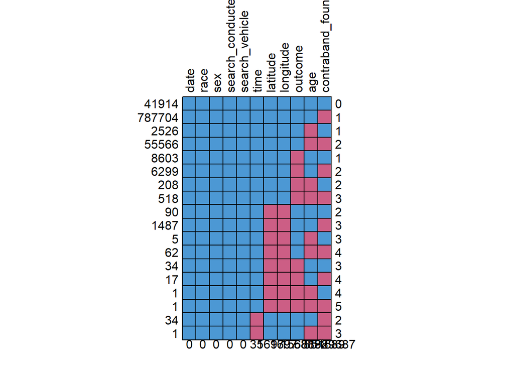

```
##        date race sex search_conducted search_vehicle time latitude longitude
## 41914     1    1   1                1              1    1        1         1
## 787704    1    1   1                1              1    1        1         1
## 2526      1    1   1                1              1    1        1         1
## 55566     1    1   1                1              1    1        1         1
## 8603      1    1   1                1              1    1        1         1
## 6299      1    1   1                1              1    1        1         1
## 208       1    1   1                1              1    1        1         1
## 518       1    1   1                1              1    1        1         1
## 90        1    1   1                1              1    1        0         0
## 1487      1    1   1                1              1    1        0         0
## 5         1    1   1                1              1    1        0         0
## 62        1    1   1                1              1    1        0         0
## 34        1    1   1                1              1    1        0         0
## 17        1    1   1                1              1    1        0         0
```

[output cut: 25 more lines]

```r
md.pattern(data, rotate.names = TRUE)
```

No i pozbawiłbym się grubo ponad 90% danych… Widzę, że problem leży głównie w zmiennej *contraband_found*.

```r
sum(is.na(data$contraband_found))
```

```
## [1] 851689
```

Sprawdzam zmienne *search_vehicle* i *search_conducted*, które w oczywisty sposób są powiązane ze zmienną *contraband_found*. Na szczęście nie mają żadnych braków.

```r
sum(!data$search_vehicle)
```

```
## [1] 851689
```

```r
sum(!data$search_conducted)
```

```
## [1] 851689
```

No tak, raczej cieżko by było znaleźć coś, nie przeszukawszy wcześniej miejsca, w którym to coś się znajduje… Przy okazji dowiadujemy się, że kontrola osobista zawsze przebiega wraz z przeszukaniem pojazdu. W każdym razie zmieniam brakujące wartości w zmiennej *contraband_found* na napis “no_search”.

```r
data$contraband_found[which(is.na(data$contraband_found))] = "no_search"
```

Teraz spokojnie mogę usunąć pozostałe rekordy z brakami (w końcu to tylko kilka % wszystkich danych).

```r
data <- na.omit(data)
```

Sprawdzę jeszcze, czy na pewno nie mam już brakujących wartości i wracam do modyfikacji struktury danych.

```
##  /\     /\
## {  `---'  }
## {  O   O  }
## ==>  V <==  No need for mice. This data set is completely observed.
##  \  \|/  /
##   `-----'
```

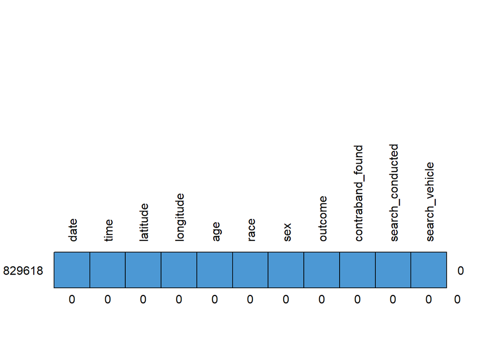

```
##        date time latitude longitude age race sex outcome contraband_found
## 829618    1    1        1         1   1    1   1       1                1
##           0    0        0         0   0    0   0       0                0
##        search_conducted search_vehicle
## 829618                1              1 0
##                       0              0 0
```

```r
md.pattern(data, rotate.names = TRUE)
```

## Modyfikacja struktury II

Zmieniam typy wybranych zmiennych (głównie logicznych i character na factor) oraz nadaję kolejność poziomów niektórym z nich.

```r
data$date <- as.Date(data$date)
data$race <- factor(data$race,
                    levels = c("white", "asian/pacific islander", "black",
                               "hispanic", "other"))
data$sex <- factor(data$sex, levels = c("male", "female"))
data$outcome <- factor(data$outcome,
                       levels = c("citation", "warning", "arrest"))
data$contraband_found <- factor(data$contraband_found,
                                levels = c("no_search", "FALSE", "TRUE"))
data$search_conducted <- factor(data$search_conducted,
                                levels = c("FALSE", "TRUE"))
data$search_vehicle <- factor(data$search_vehicle,
                              levels = c("FALSE", "TRUE"))
```

Zmienną *time* postanawiam wykorzystać do stworzenia nowej zmiennej *time_of_day*.

```r
data$time <- as.POSIXct(data$time, format = "%H:%M:%S")
help <- as.POSIXct(c("06:00:00", "12:00:00", "18:00:00", "24:00:00"),
                   format = "%H:%M:%S")
data <- data %>%
  mutate(time_of_day = case_when(time >= help[1] & time < help[2] ~ "morning",
                                 time >= help[2] & time < help[3] ~ "afternoon",
                                 time >= help[3] & time < help[4] ~ "evening",
                                 TRUE ~ "night"))
```

Nowej zmiennej zmieniam od razu typ na kategoryczny i nadaję odpowiednią kolejność poziomów, oraz pozbywam się zmiennej *time* - spełniła już swoje zadanie.

```r
data$time_of_day <- factor(data$time_of_day,
                           levels = c("morning", "afternoon", "evening", "night"))
data <- subset(data, select = -time)
```

Na koniec wyświetlam statystyki opisowe dla gotowego do analizy zestawu danych.

```r
summary(data)
```

```
##       date               latitude       longitude           age
##  Min.   :2007-01-01   Min.   :36.04   Min.   :-123.8   Min.   : 10.00
##  1st Qu.:2009-01-04   1st Qu.:37.74   1st Qu.:-122.4   1st Qu.: 27.00
##  Median :2010-12-31   Median :37.77   Median :-122.4   Median : 35.00
##  Mean   :2011-04-11   Mean   :37.76   Mean   :-122.4   Mean   : 37.89
##  3rd Qu.:2013-05-16   3rd Qu.:37.78   3rd Qu.:-122.4   3rd Qu.: 47.00
##  Max.   :2016-06-30   Max.   :39.93   Max.   :-113.3   Max.   :100.00
##                      race            sex             outcome
##  white                 :346538   male  :584183   citation:588945
##  asian/pacific islander:145582   female:245435   warning :229376
##  black                 :138345                   arrest  : 11297
##  hispanic              :103268
##  other                 : 95885
##
##   contraband_found  search_conducted search_vehicle    time_of_day
##  no_search:787704   FALSE:787704     FALSE:787704   morning  :183535
##  FALSE    : 34787   TRUE : 41914     TRUE : 41914   afternoon:263982
##  TRUE     :  7127                                   evening  :283076
##                                                     night    : 99025
##
##
```

Jak widać ewentualne wartości odstające są całkowicie pomijalne (np. wartość maksymalna w zmiennej *longitude*).

# Badanie zależności między zmiennymi

## Zatrzymania

Na początku sprawdzam jaki odsetek zatrzymań stanowią kobiety, a jaki mężczyźni.

```r
prop.table(table(data$sex))
```

```
##
##     male   female
## 0.704159 0.295841
```

Czy rasa kierowcy zmienia jakoś te proporcje?

```r
prop.table(table(data$race, data$sex), 1)
```

```
##
##                               male    female
##   white                  0.6658404 0.3341596
##   asian/pacific islander 0.6957454 0.3042546
##   black                  0.7021866 0.2978134
##   hispanic               0.7655808 0.2344192
##   other                  0.7921156 0.2078844
```

W przypadku Azjatów i osób czarnych oraz z rejonów Oceanii nie widać większych zmian. Największe różnice można zaobserwować u Latynosów i osób, których rasa została określona jako “other”, gdzie wyraźnie większy odsetek mężczyzn zostaje zatrzymany przez policję. Z kolei u rasy białej to większy odsetek kobiet zostaje zatrzymany do kontroli.

Zobaczmy może jeszcze jakiej rasy są zatrzymywane osoby.

```r
prop.table(table(data$race, data$sex), 2)
```

```
##
##                                male     female
##   white                  0.39497726 0.47181127
##   asian/pacific islander 0.17338403 0.18047141
##   black                  0.16629036 0.16786929
##   hispanic               0.13533430 0.09863304
##   other                  0.13001405 0.08121499
```

Pewnie można by było coś ciekawego tutaj napisać, ale opieram się wyłącznie na wybranym zestawie danych, w którym nie ma żadnych informacji odnośnie demografii rejonu San Francisco.

## Wiek zatrzymanych

Teraz sprawdzę w jakim wieku są zatrzymywane osoby (od razu z podziałem na płeć).

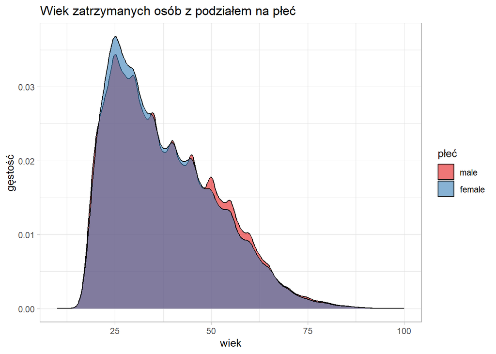

```r
data %>%
  ggplot(aes(x = age, fill = sex)) +
  geom_density(alpha = 0.6) +
  scale_fill_brewer(palette="Set1") +
  theme_light() +
  labs(title = "Wiek zatrzymanych osób z podziałem na płeć",
       x = "wiek",
       y = "gęstość",
       fill = "płeć")
```

Obydwa rozkłady są do siebie bardzo podobne, a zatrzymywane są głównie osoby do 50 roku życia. Potwierdzę to jeszcze wyznaczając kilka statystyk opisowych i rysując odpowiednie wykresy pudełkowe.

```r
data %>%
  group_by(sex) %>%
  summarise(srednia = mean(age),
            mediana = median(age),
            odchylenie_standardowe = sd(age),
            rozstep_cwiartkowy = IQR(age))
```

```
## # A tibble: 2 × 5
##   sex    srednia mediana odchylenie_standardowe rozstep_cwiartkowy
##   <fct>    <dbl>   <int>                  <dbl>              <dbl>
## 1 male      38.0      35                   13.7                 21
## 2 female    37.5      35                   13.5                 20
```

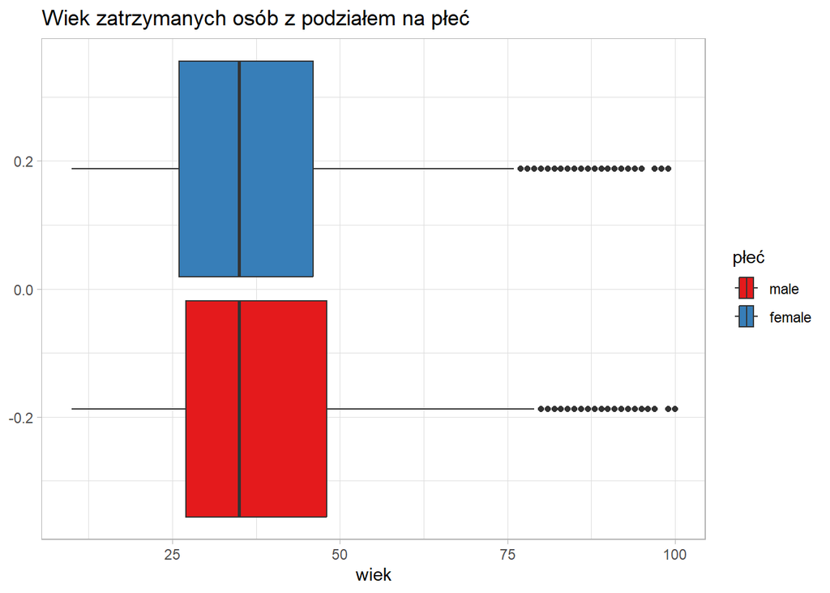

```r
data %>%
  ggplot(aes(x = age, fill = sex)) +
  geom_boxplot() +
  scale_fill_brewer(palette="Set1") +
  theme_light() +
  labs(title = "Wiek zatrzymanych osób z podziałem na płeć",
       x = "wiek",
       fill = "płeć")
```

Tutaj wyraźnie widać, że osoby do 50 roku życia stanowią ponad 75% wszystkich zatrzymań. Czy rasa w tym wypadku coś zmienia?

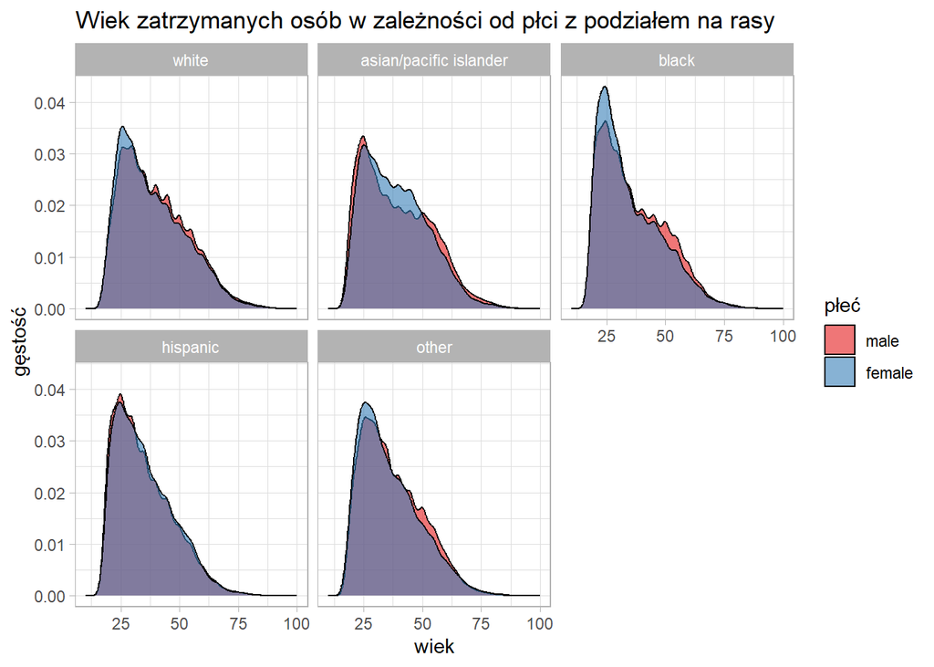

```r
data %>%
  ggplot(aes(x = age, fill = sex)) +
  geom_density(alpha = 0.6) +
  scale_fill_brewer(palette="Set1") +
  theme_light() +
  facet_wrap(~ race) +
  labs(title = "Wiek zatrzymanych osób w zależności od płci z podziałem na rasy",
       x = "wiek",
       y = "gęstość",
       fill = "płeć")
```

Ciężko powiedzieć. Wyznaczę kilka statystyk opisowych w zależności od rasy dla każdej płci osobno.

```r
data %>%
  filter(sex == "male") %>%
  group_by(race) %>%
  summarise(srednia = mean(age),
            mediana = median(age),
            odchylenie_standardowe = sd(age),
            rozstep_cwiartkowy = IQR(age))
```

```
## # A tibble: 5 × 5
##   race                 srednia mediana odchylenie_standardowe rozstep_cwiartkowy
##   <fct>                  <dbl>   <dbl>                  <dbl>              <dbl>
## 1 white                   39.7      37                   13.9                 21
## 2 asian/pacific islan…    39.0      37                   14.5                 24
## 3 black                   36.5      33                   13.7                 21
## 4 hispanic                34.8      32                   12.2                 18
## 5 other                   37.2      35                   12.7                 19
```

```r
data %>%
  filter(sex == "female") %>%
  group_by(race) %>%
  summarise(srednia = mean(age),
            mediana = median(age),
            odchylenie_standardowe = sd(age),
            rozstep_cwiartkowy = IQR(age))
```

```
## # A tibble: 5 × 5
##   race                 srednia mediana odchylenie_standardowe rozstep_cwiartkowy
##   <fct>                  <dbl>   <dbl>                  <dbl>              <dbl>
## 1 white                   38.6      36                   13.8                 21
## 2 asian/pacific islan…    38.8      37                   13.3                 20
## 3 black                   34.9      31                   13.2                 20
## 4 hispanic                35.2      33                   12.1                 18
## 5 other                   36.2      33                   12.7                 18
```

Między płciami różnice występują, ale są raczej niewielkie. Jeżeli chodzi o rasy to średnio najstarsi są Azjaci, osoby z rejonów Oceanii oraz białe. Średnio najmłodsi są Latynosi i osoby czarne, a osoby określone jako “other”, znajdują się gdzieś pomiędzy tymi grupami.

## Wynik zatrzymania

Zajmę się teraz zmienną *outcome* i jej związkami z pozostałymi zmiennymi. Zacznę od sprawdzenia zależności między płcią, a wynikiem zatrzymania.

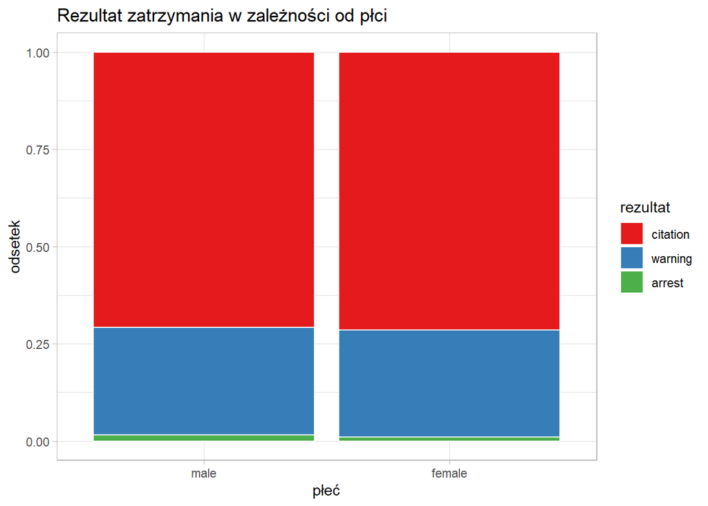

```r
data %>%
  ggplot(aes(x = sex, fill = outcome)) +
  geom_bar(position = "fill", color = "white") +
  scale_fill_brewer(palette="Set1") +
  theme_light() +
  labs(title = "Rezultat zatrzymania w zależności od płci",
       x = "płeć",
       y = "odsetek",
       fill = "rezultat")
```

Poza większym odestkiem aresztowań mężczyzn, nie ma innych istotnych różnic. W przypadku obydwu płci około 70% zatrzymań kończy się mandatem, a coś między 25-30% ostrzeżeniem. Sprawdźmy to dokładniej.

```r
prop.table(table(data$sex, data$outcome), 1)
```

```
##
##             citation     warning      arrest
##   male   0.707858668 0.276880703 0.015260629
##   female 0.714755434 0.275539349 0.009705217
```

```r
prop.table(table(data$sex, data$outcome), 2)
```

```
##
##           citation   warning    arrest
##   male   0.7021352 0.7051697 0.7891476
##   female 0.2978648 0.2948303 0.2108524
```

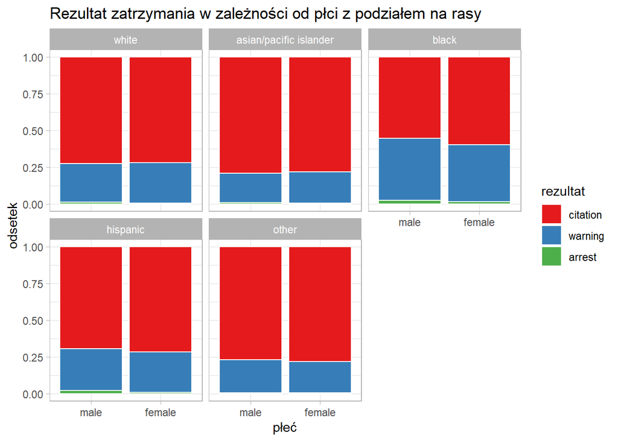

```r
data %>%
  ggplot(aes(x = sex, fill = outcome)) +
  geom_bar(color = "white",
           position = "fill") +
  scale_fill_brewer(palette="Set1") +
  theme_light() +
  facet_wrap(~ race) +
  labs(title = "Rezultat zatrzymania w zależności od płci z podziałem na rasy",
     x = "płeć",
     y = "odsetek",
     fill = "rezultat")
```

Najbardziej rzuca się w oczy zdecydowanie większy odsetek osób czarnych dostających tylko ostrzeżenia. Widać też, że największy odsetek aresztowań ma miejsce przy zatrzymaniach mężczyzn tej rasy. Najwięcej zatrzymań kończy się mandatem (ponad 75%) w przypadku Azjatów, osób z rejonów Oceanii i tych zaklasyfikowanych jako “other”.

Sprawdzę jeszcze jak wygląda sytuacja w zależności od rasy z podziałem na płcie.

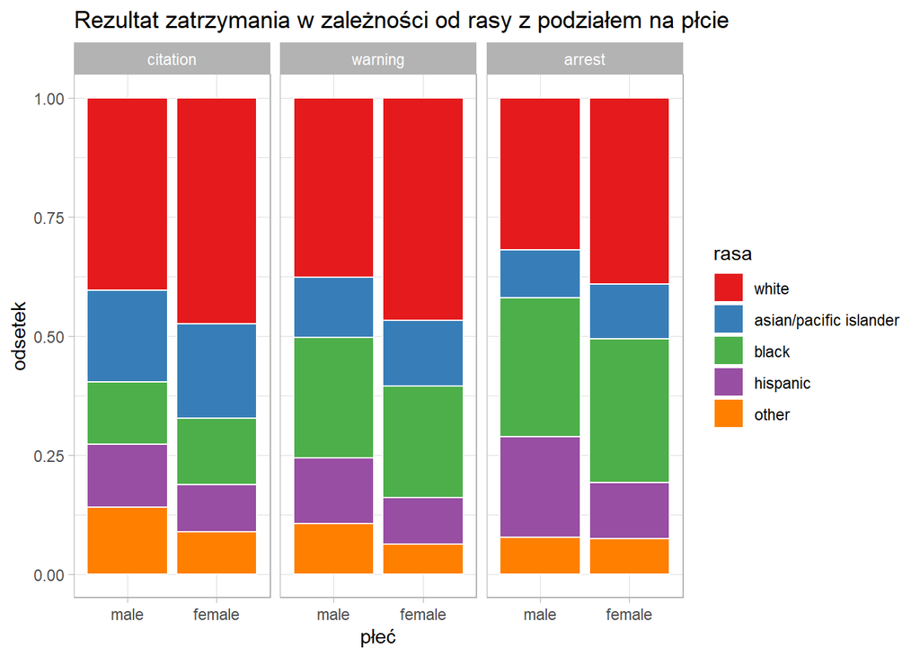

```r
data %>%
  ggplot(aes(x = sex, fill = race)) +
  geom_bar(color = "white",
           position = "fill") +
  scale_fill_brewer(palette="Set1") +
  theme_light() +
  facet_wrap(~ outcome) +
  labs(title = "Rezultat zatrzymania w zależności od rasy z podziałem na płcie",
     x = "płeć",
     y = "odsetek",
     fill = "rasa")
```

Kobiety rasy białej stanowią większy odsetek wszystkich wyników zatrzymań wśród kobiet, niż biali mężczyźni wśród mężczyzn. Równoważy to większy odsetek Latynosów i “innych” wśród mężczyzn w stosunku do odestka kobiet swoich grup wśród wszystkich kobiet. Największa dysproporcja między płciami występuje w przypadku aresztowań Latynosów.

Czy wiek odgrywa tutaj jakąś istotną rolę?

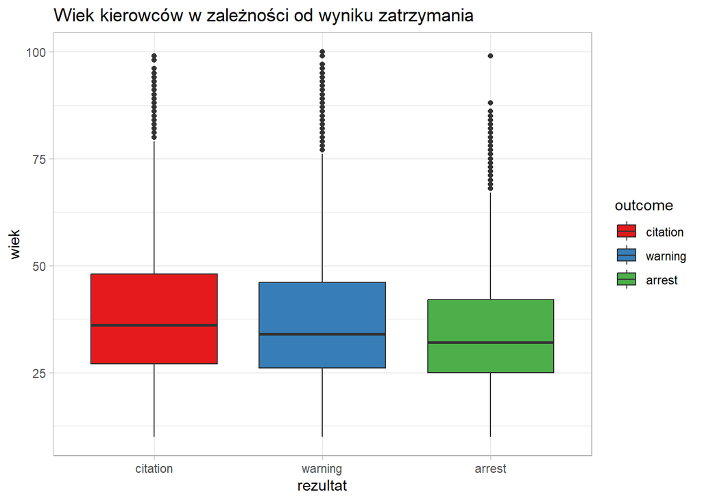

```r
data %>%
  ggplot(aes(x = outcome, y = age, fill=outcome)) +
  geom_boxplot() +
  scale_fill_brewer(palette="Set1") +
  theme_light() +
  labs(title = "Wiek kierowców w zależności od wyniku zatrzymania",
     x = "rezultat",
     y = "wiek")
```

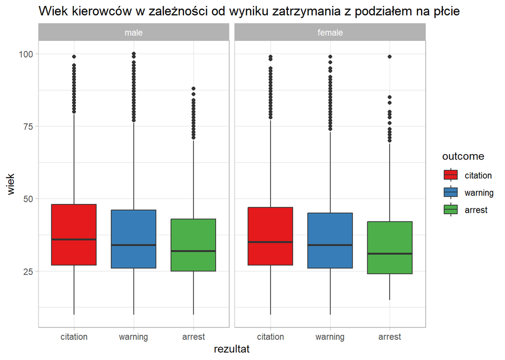

```r
data %>%
  ggplot(aes(x = outcome, y = age, fill=outcome)) +
  geom_boxplot() +
  scale_fill_brewer(palette="Set1") +
  theme_light() +
  facet_wrap(~ sex) +
  labs(title = "Wiek kierowców w zależności od wyniku zatrzymania z podziałem na płcie",
     x = "rezultat",
     y = "wiek")
```

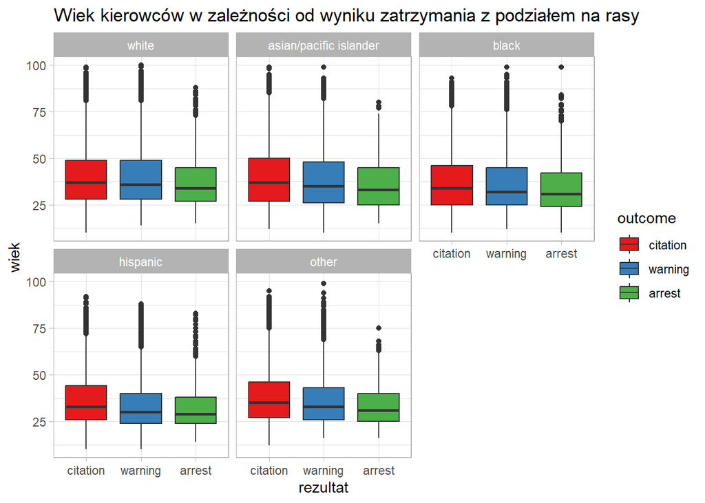

```r
data %>%
  ggplot(aes(x = outcome, y = age, fill=outcome)) +
  geom_boxplot() +
  scale_fill_brewer(palette="Set1") +
  theme_light() +
  facet_wrap(~ race) +
  labs(title = "Wiek kierowców w zależności od wyniku zatrzymania z podziałem na rasy",
     x = "rezultat",
     y = "wiek")
```

Nie widać tutaj jakichś specjalnych różnic. Co można powiedzieć na pewno, to to, że osoby aresztowane są średnio najmłodsze, a osoby dostające mandat średnio najstarsze.

## Przeszukiwanie zatrzymanych

Czas najwyższy zająć się zmiennymi *search_conducted* i *contrabound_found* (jak już zostało ustalone zmienne *search_conducted* i *search_vehicle* zawierają dokładnie to samo). Kto był częściej przeszukiwany - kobiety czy mężczyźni?

```r
prop.table(table(data$sex, data$search_conducted), 1)
```

```
##
##               FALSE       TRUE
##   male   0.93999312 0.06000688
##   female 0.97205370 0.02794630
```

```r
prop.table(table(data$sex, data$search_conducted), 2)
```

```
##
##              FALSE      TRUE
##   male   0.6971248 0.8363554
##   female 0.3028752 0.1636446
```

Widać, że mężczyźni byli przeszukiwani ponad dwa razy częściej od kobiet. Jednocześnie prawie 84% wszystkich przeszukań dotyczyło mężczyzn. U kogo częściej znajdowano kontrabandę?

```r
data %>%
  group_by(sex) %>%
  summarise(contraband_rate = sum(contraband_found == "TRUE") / length(contraband_found))
```

```
## # A tibble: 2 × 2
##   sex    contraband_rate
##   <fct>            <dbl>
## 1 male           0.00936
## 2 female         0.00677
```

Proporcje się zmieniły. W sumie to należałoby sprawdzić czy przeszukania były uzasadnione tj. jaki odsetek przeszukań zakończył się znalezieniem kontrabandy.

```r
data %>%
  group_by(sex) %>%
  summarise(success_rate = sum(contraband_found == "TRUE") / sum(search_conducted == "TRUE"))
```

```
## # A tibble: 2 × 2
##   sex    success_rate
##   <fct>         <dbl>
## 1 male          0.156
## 2 female        0.242
```

Okazuje się, że przeszukania kobiet były wyraźnie bardziej uzasadnione. Zobaczmy jak to wygląda w zależności od rasy.

```r
prop.table(table(filter(data, search_conducted == "TRUE")$race))
```

```
##
##                  white asian/pacific islander                  black
##             0.22350527             0.05661593             0.46476118
##               hispanic                  other
##             0.18867204             0.06644558
```

Osoby czarne stanowią zdecydowanie największy odsetek przeszukiwanych osób - ponad 46%. Czy słusznie?

```r
data %>%
  group_by(race) %>%
  summarise(success_rate = sum(contraband_found == "TRUE") / sum(search_conducted == "TRUE"))
```

```
## # A tibble: 5 × 2
##   race                   success_rate
##   <fct>                         <dbl>
## 1 white                        0.276
## 2 asian/pacific islander       0.391
## 3 black                        0.0978
## 4 hispanic                     0.129
## 5 other                        0.247
```

Wygląda na to, że nie - u osób czarnych najrzadziej znajduje się kontrabandę. Dla równowagi największy odsetek sukcesów odnotowuje się u osób najrzadziej przeszukiwanych - Azjatów i z Oceanii. Szkoda, że w danych nie było jakichś informacji odnośnie samych kontraband.

## Data i pora dnia zatrzymania

Mam jeszcze kilka zmiennych, których nie ruszyłem. Zobaczmy jak zmieniała się liczba zatrzymań w kolejnych latach.

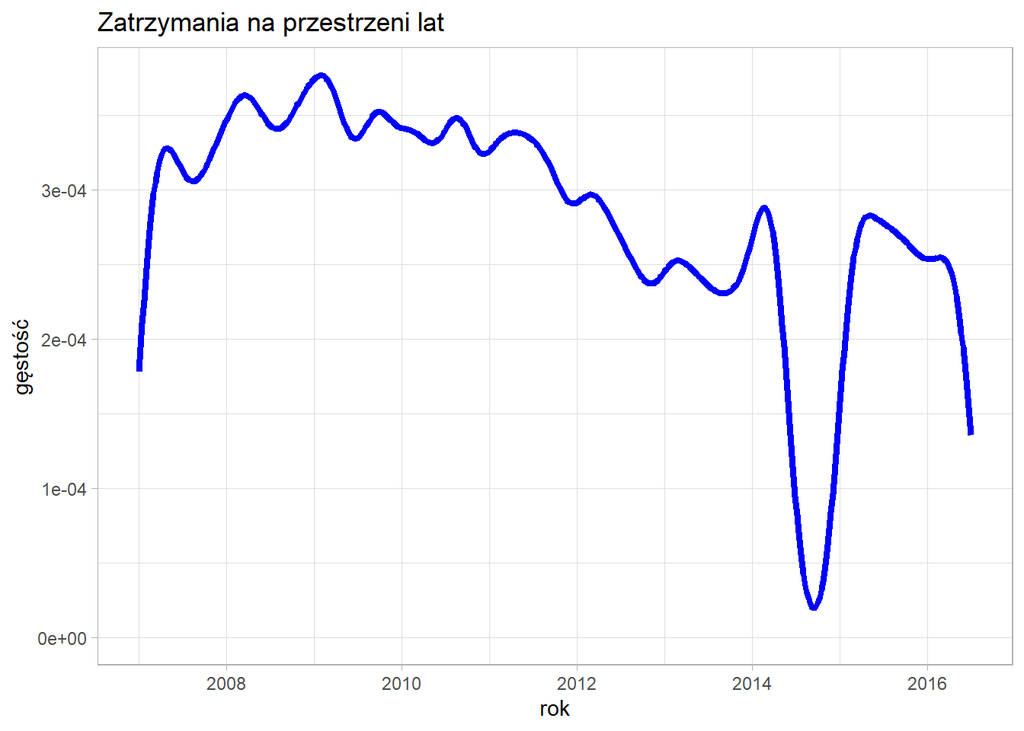

```r
data %>%
  ggplot(aes(x = date)) +
  geom_density(color = "blue", linewidth = 1.5) +
  theme_light() +
  labs(title = "Zatrzymania na przestrzeni lat",
     x = "rok",
     y = "gęstość")
```

Poza silnym spadkiem w 2014 roku nie ma tu w zasadzie niczego interesującego. Za mały okres żeby wyciągnąć jakieś fajne wnioski.

Kontynuując, o jakiej porze dnia ma miejsce najwięcej zatrzymań?

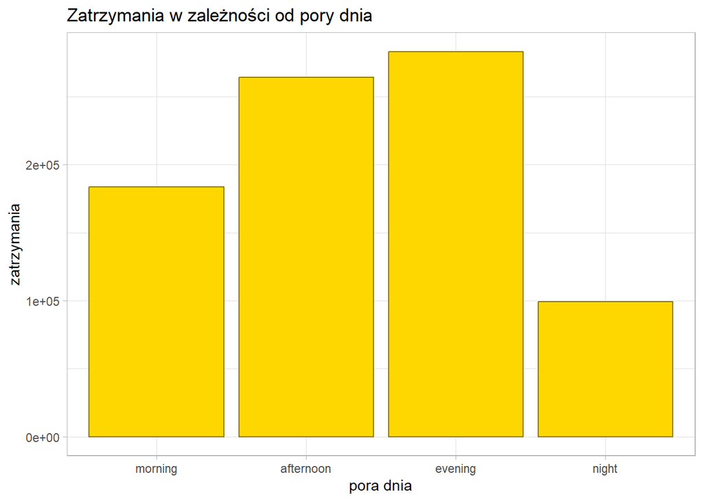

```r
data %>%
  ggplot(aes(x = time_of_day)) +
  geom_bar(color = "gold4", fill = "gold") +
  theme_light() +
  labs(title = "Zatrzymania w zależności od pory dnia",
       x = "pora dnia",
       y = "zatrzymania")
```

Zdecydowanie najwięcej zatrzymań ma miejsce po południu i wieczorami, co oczywiście na sens - ludzie wracają do domów po pracy czy innych wieczornych rozrywkach. Ciekawe czy jest jakaś zależność między porą dnia a wynikiem zatrzymania.

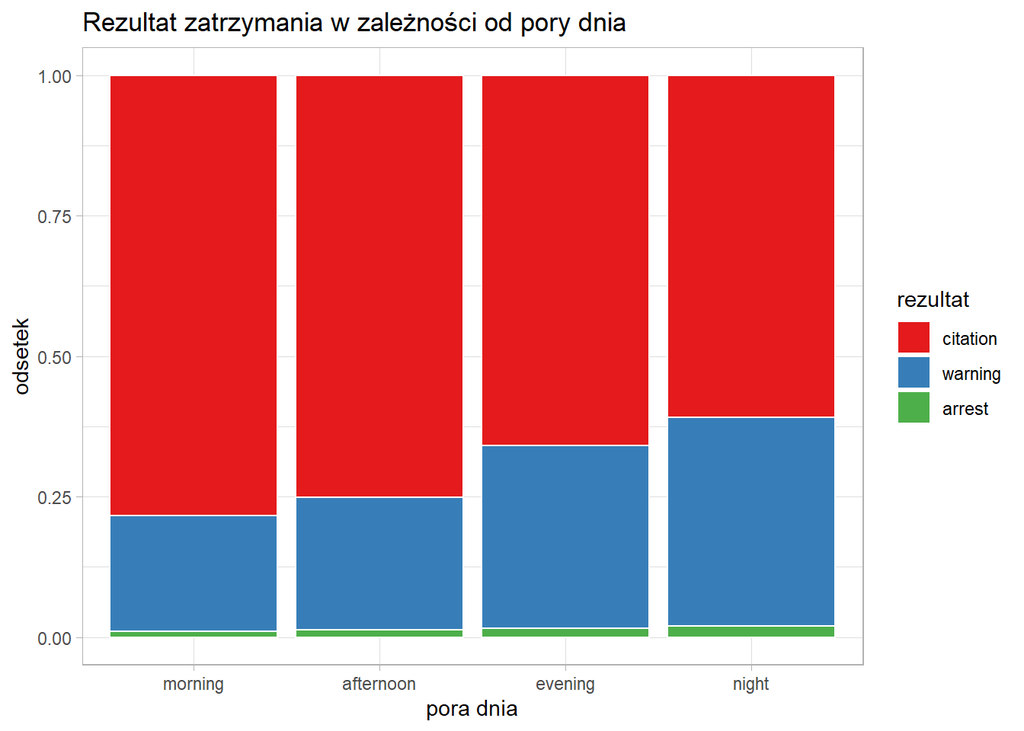

```r
data %>%
  ggplot(aes(x = time_of_day, fill = outcome)) +
  geom_bar(position = "fill", color = "white") +
  scale_fill_brewer(palette="Set1") +
  theme_light() +
  labs(title = "Rezultat zatrzymania w zależności od pory dnia",
       x = "pora dnia",
       y = "odsetek",
       fill = "rezultat")
```

Okazuje się, że im późniejsza pora, tym więcej ostrzeżen i aresztowań. Sprawdzę jeszcze zależność pory dnia od rasy kierowcy.

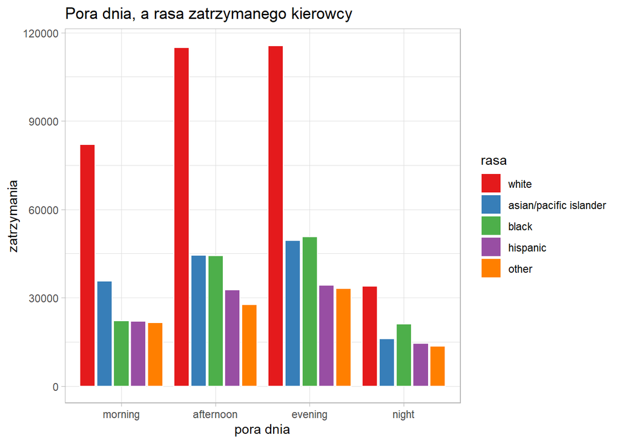

```r
data %>%
  ggplot(aes(x = time_of_day, fill = race)) +
  geom_bar(color = "white", position = "dodge2") +
  scale_fill_brewer(palette="Set1") +
  theme_light() +
  labs(title = "Pora dnia, a rasa zatrzymanego kierowcy",
       x = "pora dnia",
       y = "zatrzymania",
       fill = "rasa")
```

Pomijając osoby białe, najwięcej zatrzymań rano i po południu dotyczy Azjatów i osób z rejonów Oceanii, a wieczorem i w nocy osób czarnych.

## Miejsce zatrzymania

Wykorzystajmy jeszcze jakoś koordynaty zatrzymań.

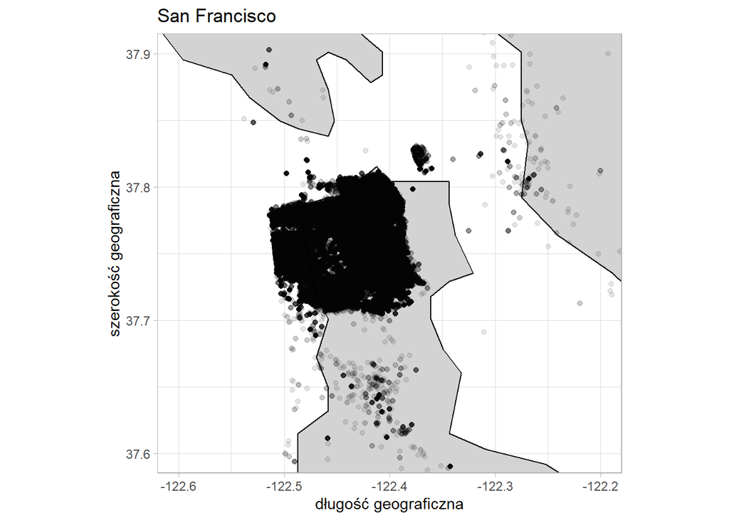

```r
map_data("state") %>%
  filter(region == "california") %>%
  ggplot(aes(x = long, y = lat)) +
  theme_light() +
  coord_quickmap(xlim = c(-122.6, -122.2),  ylim = c(37.6, 37.9)) +
  geom_polygon(color = "black", fill = "lightgray") +
  geom_point(data, mapping = aes(x = longitude, y = latitude), alpha = 0.1) +
  labs(title = "San Francisco",
      x = "długość geograficzna",
      y = "szerokość geograficzna")
```

No tak, nie wiem czego się spodziewałem… Ale szkoda usuwać, zwłaszcza, że kilka minut trwa nakładanie wszystkich punktów (które swoją drogą wydają się być przesunięte w lewą stronę) na mapę (albo to mapa jest przesunięta względem punktów na prawo).